# ID2223 TensorFlow Lab 2

Tianze Wang

1. A Quick Recap
2. Introduction to Computer Vision
3. Introduction to Convolutions
4. Convolutional Neural Networks
5. More Complex Images

## Section 1: A Quick Recap

Consider the following sets of numbers. What is the `relationship` between them?

| x | y |
| --- | --- |
| -1 | -2 |
| 0 | 1 |
| 1 | 4 |
| 2 | 7 |
| 3 | 10 |
| 4 | 13 |

Now let's look at how to train a `ML model` to spot the patterns between these items of data.

```python
import tensorflow as tf
import numpy as np
print(tf.__version__)
```

```
2.0.0
```

### Prepare training Data

| x | y |
| --- | --- |
| -1 | -2 |
| 0 | 1 |
| 1 | 4 |
| 2 | 7 |
| 3 | 10 |
| 4 | 13 |

```python
# training data
X_train = np.array([-1.0, 0.0, 1.0, 2.0, 3.0, 4.0], dtype=float)
y_train = np.array([-2.0, 1.0, 4.0, 7.0, 10.0, 13.0], dtype=float)
```

### Define the model

```python
model = tf.keras.Sequential([tf.keras.layers.Dense(units=1, input_shape=[1])])
model.compile(optimizer='sgd', loss='mean_squared_error')
```

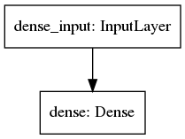

```python
# plot the model
tf.keras.utils.plot_model(model)
```

```python
# model summary
model.summary()
```

```
Model: "sequential"
_________________________________________________________________
Layer (type)                 Output Shape              Param #
=================================================================
dense (Dense)                (None, 1)                 2
=================================================================
Total params: 2
Trainable params: 2
Non-trainable params: 0
_________________________________________________________________
```

### Train and evaluate

```python
model.fit(X_train, y_train, epochs=500)
```

```
Train on 6 samples
```

```
<tensorflow.python.keras.callbacks.History at 0x7fb86422d7f0>
```

```python
print(model.predict([10]))
```

```
[[30.996334]]
```

```python
model.evaluate([10, 11], [31, 34])
```

```
1.5523408364970237e-05
```

[figure not shown]

## Section 2: Introduction to Computer Vision

In the previous section, we have seen how to use neural networks to `map` the relationship between two variables (i.e., x and y).

However, in that instance, it is a bit of `overkill` because it would have been easier to write the funtion $$y = 3x + 1$$ , insteal of using ML to learn the relationship bwtween $x$ and $y$ for a fixed set of values.

But what if we are dealing with a case where writing `rules` like $y = 3x + 1$ is much more difficult? `Computre Vision` problems serve as good examples in this case. Let's take a look at a scenario where we want to `recognize different items of clothing`, trained from a dataset containing 10 different types.

### A new dataset: `Fashion MNIST`

We will train a neural network to recognize items of clothing from a common dataset called `Fashion MNIST`. You can learn more about this dataset [here](https://github.com/zalandoresearch/fashion-mnist).

It contains 70,000 items of clothing in 10 different categories. Each item of clothing is in a 28x28 greyscale image. You can see some examples here:

[figure not shown]

```python
# The Fashion MNIST data is available directly in the tf.keras.datasets API.
mnist_dataset = tf.keras.datasets.fashion_mnist
```

```python
# The load_data() function of this object will give two sets of two lists, which will be the training and testing data
(X_train, y_train), (X_test, y_test) = mnist_dataset.load_data()
```

```python
print("Shape of X_train = ", X_train.shape)
print("Shape of y_train = ", y_train.shape)
print("Shape of X_test = ", X_test.shape)
print("Shape of y_test = ", y_test.shape)
```

```
Shape of X_train =  (60000, 28, 28)
Shape of y_train =  (60000,)
Shape of X_test =  (10000, 28, 28)
Shape of y_test =  (10000,)
```

```python
print(y_train[0])
print(X_train[0])
```

```
9
[[  0   0   0   0   0   0   0   0   0   0   0   0   0   0   0   0   0   0
    0   0   0   0   0   0   0   0   0   0]
 [  0   0   0   0   0   0   0   0   0   0   0   0   0   0   0   0   0   0
    0   0   0   0   0   0   0   0   0   0]
 [  0   0   0   0   0   0   0   0   0   0   0   0   0   0   0   0   0   0
    0   0   0   0   0   0   0   0   0   0]
 [  0   0   0   0   0   0   0   0   0   0   0   0   1   0   0  13  73   0
    0   1   4   0   0   0   0   1   1   0]
 [  0   0   0   0   0   0   0   0   0   0   0   0   3   0  36 136 127  62
   54   0   0   0   1   3   4   0   0   3]
 [  0   0   0   0   0   0   0   0   0   0   0   0   6   0 102 204 176 134
  144 123  23   0   0   0   0  12  10   0]
 [  0   0   0   0   0   0   0   0   0   0   0   0   0   0 155 236 207 178
  107 156 161 109  64  23  77 130  72  15]
 [  0   0   0   0   0   0   0   0   0   0   0   1   0  69 207 223 218 216
  216 163 127 121 122 146 141  88 172  66]
 [  0   0   0   0   0   0   0   0   0   1   1   1   0 200 232 232 233 229
  223 223 215 213 164 127 123 196 229   0]
 [  0   0   0   0   0   0   0   0   0   0   0   0   0 183 225 216 223 228
  235 227 224 222 224 221 223 245 173   0]
 [  0   0   0   0   0   0   0   0   0   0   0   0   0 193 228 218 213 198
  180 212 210 211 213 223 220 243 202   0]
 [  0   0   0   0   0   0   0   0   0   1   3   0  12 219 220 212 218 192
  169 227 208 218 224 212 226 197 209  52]
 [  0   0   0   0   0   0   0   0   0   0   6   0  99 244 222 220 218 203
  198 221 215 213 222 220 245 119 167  56]
 [  0   0   0   0   0   0   0   0   0   4   0   0  55 236 228 230 228 240
  232 213 218 223 234 217 217 209  92   0]
 [  0   0   1   4   6   7   2   0   0   0   0   0 237 226 217 223 222 219
  222 221 216 223 229 215 218 255  77   0]
 [  0   3   0   0   0   0   0   0   0  62 145 204 228 207 213 221 218 208
  211 218 224 223 219 215 224 244 159   0]
 [  0   0   0   0  18  44  82 107 189 228 220 222 217 226 200 205 211 230
  224 234 176 188 250 248 233 238 215   0]
 [  0  57 187 208 224 221 224 208 204 214 208 209 200 159 245 193 206 223
  255 255 221 234 221 211 220 232 246   0]
 [  3 202 228 224 221 211 211 214 205 205 205 220 240  80 150 255 229 221
  188 154 191 210 204 209 222 228 225   0]
 [ 98 233 198 210 222 229 229 234 249 220 194 215 217 241  65  73 106 117
  168 219 221 215 217 223 223 224 229  29]
 [ 75 204 212 204 193 205 211 225 216 185 197 206 198 213 240 195 227 245
  239 223 218 212 209 222 220 221 230  67]
 [ 48 203 183 194 213 197 185 190 194 192 202 214 219 221 220 236 225 216
  199 206 186 181 177 172 181 205 206 115]
 [  0 122 219 193 179 171 183 196 204 210 213 207 211 210 200 196 194 191
  195 191 198 192 176 156 167 177 210  92]
 [  0   0  74 189 212 191 175 172 175 181 185 188 189 188 193 198 204 209
  210 210 211 188 188 194 192 216 170   0]
 [  2   0   0   0  66 200 222 237 239 242 246 243 244 221 220 193 191 179
  182 182 181 176 166 168  99  58   0   0]
 [  0   0   0   0   0   0   0  40  61  44  72  41  35   0   0   0   0   0
    0   0   0   0   0   0   0   0   0   0]
 [  0   0   0   0   0   0   0   0   0   0   0   0   0   0   0   0   0   0
    0   0   0   0   0   0   0   0   0   0]
 [  0   0   0   0   0   0   0   0   0   0   0   0   0   0   0   0   0   0
    0   0   0   0   0   0   0   0   0   0]]
```

### Visualizing the dataset

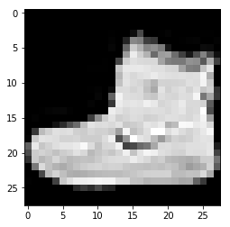

```python
import matplotlib.pyplot as plt

plt.imshow(X_train[0], cmap='gray')
plt.show()
```

Note that the values in the image are between 0 and 255. When training a neural network, it is easier that if we can convert every values to between 0 and 1, which is a process normally referred to as `normalizing`.

```python
print("Before normalizing: ")
print("\t min of train is {}, max of train is {}".format(np.min(X_train), np.max(X_train)))
print("\t min of test is {}, max of test is {}".format(np.min(X_test), np.max(X_test)))

X_train = X_train/255
X_test = X_test/255

print("After normalizing: ")
print("\t min of train is {}, max of train is {}".format(np.min(X_train), np.max(X_train)))
print("\t min of test is {}, max of test is {}".format(np.min(X_test), np.max(X_test)))
```

```
Before normalizing:
	 min of train is 0, max of train is 255
	 min of test is 0, max of test is 255
After normalizing:
	 min of train is 0.0, max of train is 1.0
	 min of test is 0.0, max of test is 1.0
```

### Define a Simple Model

```python
# define the model
model = tf.keras.models.Sequential()
model.add(tf.keras.layers.Flatten())
model.add(tf.keras.layers.Dense(128, activation=tf.nn.relu))
model.add(tf.keras.layers.Dense(10, activation=tf.nn.softmax))
```

### Compile the Model

```python
# compile the model
model.compile(optimizer = tf.optimizers.SGD(),
              loss = 'sparse_categorical_crossentropy',
              metrics=['accuracy'])
```

### Train the model

```python
# train for 5 epochs
model.fit(X_train, y_train, epochs=5)
```

```
Train on 60000 samples
```

```
<tensorflow.python.keras.callbacks.History at 0x7fb8836002e8>
```

### Prediction and evaluation

```python
# prediction on unseen data
classifications = model.predict(X_test)

print(classifications[0])
print("True label is ", y_test[0])
print("The predicted label is ", np.argmax(classifications[0]))
```

```
[4.0976588e-06 4.8142583e-06 1.8533812e-05 7.6556162e-06 3.0518473e-05
 1.0107300e-01 7.4795840e-05 2.0220113e-01 4.4535613e-03 6.9213188e-01]
True label is  9
The predicted label is  9
```

```python
# evaluation on test set
loss, acc = model.evaluate(X_test, y_test, verbose=0)
print("loss on test set is : ", loss)
print("accuracy on test set is : ", acc)
```

```
loss on test set is :  0.44848056111335755
accuracy on test set is :  0.8416
```

### More Neurons!

```python
# the data
(X_train, y_train),  (X_test, y_test) = tf.keras.datasets.fashion_mnist.load_data()

X_train = X_train/255.0
X_test = X_test/255.0
```

```python
# define the model
model = tf.keras.models.Sequential()
model.add(tf.keras.layers.Flatten())
model.add(tf.keras.layers.Dense(1024, activation=tf.nn.relu))
model.add(tf.keras.layers.Dense(10, activation=tf.nn.softmax))
```

```python
# compile the model
model.compile(optimizer = tf.optimizers.SGD(),
              loss = 'sparse_categorical_crossentropy',
              metrics=['accuracy'])
```

```python
# train the model
model.fit(X_train, y_train, epochs=5)
```

```
Train on 60000 samples
```

```
<tensorflow.python.keras.callbacks.History at 0x7fb83c4ddac8>
```

```python
# a single prediction
predictions = model.predict(X_test)

print(predictions[0])
print("The predicted label is ", np.argmax(predictions[0]))
```

```
[3.9984065e-05 1.0286058e-05 6.5077933e-05 3.2205684e-05 4.0681407e-05
 1.2416209e-01 8.3608582e-05 2.0007513e-01 7.2584585e-03 6.6823244e-01]
The predicted label is  9
```

```python
print("True label is ", y_test[0])
```

```
True label is  9
```

```python
# evaluation on test set
loss, acc = model.evaluate(X_test, y_test, verbose=0)
print("loss on test set is : ", loss)
print("accuracy on test set is : ", acc)
```

```
loss on test set is :  0.43644546914100646
accuracy on test set is :  0.8483
```

### Let's go DEEP! More Layers!

```python
# get the data
(X_train, y_train),  (X_test, y_test) = tf.keras.datasets.fashion_mnist.load_data()
X_train = X_train/255.0
X_test = X_test/255.0
```

```python
# define the model
model = tf.keras.models.Sequential()
model.add(tf.keras.layers.Flatten())
model.add(tf.keras.layers.Dense(1024, activation=tf.nn.relu))
model.add(tf.keras.layers.Dense(128, activation=tf.nn.relu))
model.add(tf.keras.layers.Dense(10, activation=tf.nn.softmax))
```

```python
# compile the model
model.compile(optimizer = tf.optimizers.SGD(),
              loss = 'sparse_categorical_crossentropy',
              metrics=['accuracy'])
```

```python
# train the model
model.fit(X_train, y_train, epochs=5)
```

```
Train on 60000 samples
```

```
<tensorflow.python.keras.callbacks.History at 0x7fb8044eabe0>
```

```python
# a single prediction
classifications = model.predict(X_test)

print(classifications[0])
print("True label is ", y_test[0])
print("The predicted label is ", np.argmax(classifications[0]))
```

```
[1.0156216e-04 5.8672558e-06 6.8080219e-05 4.3952998e-05 5.2518335e-05
 7.3960766e-02 2.0629779e-04 1.3262554e-01 1.0721110e-02 7.8221434e-01]
True label is  9
The predicted label is  9
```

```python
# evaluation on test set
loss, acc = model.evaluate(X_test, y_test, verbose=0)
print("loss on test set is : ", loss)
print("accuracy on test set is : ", acc)
```

```
loss on test set is :  0.4090584322690964
accuracy on test set is :  0.8535
```

## Section 3: Convolutions

### Limitations of the previous DNN

In the previous section, we saw how to train an image classifier for fashion items using the `Fashion MNIST` dataset. This gave us a pretty accuract classifier, but there was an obvious constraint: the images were 28x28, grey scale and the item was centered in the image.

For example here are a couple of the images in Fashion MNIST

[figure not shown]

The DNN that you created simply learned from the raw pixels what made up a sweater, and what made up `a boot` in this context. But consider how it might classify this image?

[figure not shown]

While it's clear that there are boots in this image, the classifier would fail for a number of reasons. First, of course, it's not 28x28 greyscale, but more importantly, the classifier was trained on the raw pixels of a left-facing boot, and not the `features` that make up what a boot is.

That's where `Convolutions` are very powerful. A convolution is a filter that passes over an image, processing it, and extracting features that show a commonolatity in the image. In this lab you'll see how they work, but processing an image to see if you can extract features from it!

Generating convolutions is very simple -- we simply scan every pixel in the image and then look at it's neighboring pixels. You multiply out the values of these pixels by the equivalent weights in a filter.

So, for example, consider this:

[figure not shown]

### Let's explore a bit

```python
import cv2
import numpy as np
from scipy import misc
i = misc.ascent()
```

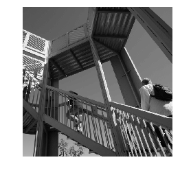

```python
import matplotlib.pyplot as plt
plt.grid(False)
plt.gray()
plt.axis('off')
plt.imshow(i)
plt.show()
```

Now we can create a filter as a 3x3 array.

```python
# This filter detects edges nicely
# It creates a convolution that only passes through sharp edges and straight
# lines.

#Experiment with different values for fun effects.
#filter = [ [0, 1, 0], [1, -4, 1], [0, 1, 0]]

# A couple more filters to try for fun!
filter = [ [-1, -2, -1], [0, 0, 0], [1, 2, 1]]
#filter = [ [-1, 0, 1], [-2, 0, 2], [-1, 0, 1]]

# If all the digits in the filter don't add up to 0 or 1, you
# should probably do a weight to get it to do so
# so, for example, if your weights are 1,1,1 1,2,1 1,1,1
# They add up to 10, so you would set a weight of .1 if you want to normalize them
weight  = 1
```

```python
i_transformed = np.copy(i)
size_x = i_transformed.shape[0]
size_y = i_transformed.shape[1]

for x in range(1,size_x-1):
  for y in range(1,size_y-1):
      convolution = 0.0
      convolution = convolution + (i[x - 1, y-1] * filter[0][0])
      convolution = convolution + (i[x, y-1] * filter[0][1])
      convolution = convolution + (i[x + 1, y-1] * filter[0][2])
      convolution = convolution + (i[x-1, y] * filter[1][0])
      convolution = convolution + (i[x, y] * filter[1][1])
      convolution = convolution + (i[x+1, y] * filter[1][2])
      convolution = convolution + (i[x-1, y+1] * filter[2][0])
      convolution = convolution + (i[x, y+1] * filter[2][1])
      convolution = convolution + (i[x+1, y+1] * filter[2][2])
      convolution = convolution * weight
      if(convolution<0):
        convolution=0
      if(convolution>255):
        convolution=255
      i_transformed[x, y] = convolution
```

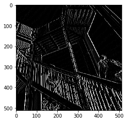

```python
# Plot the image. Note the size of the axes -- they are 512 by 512
plt.gray()
plt.grid(False)
plt.imshow(i_transformed)
#plt.axis('off')
plt.show()
```

So, consider the following filter values, and their impact on the image.

Using -1,0,1,-2,0,2,-1,0,1 gives us a very strong set of vertical lines:

[figure not shown]

Using -1, -2, -1, 0, 0, 0, 1, 2, 1 gives us horizontal lines:

[figure not shown]

### Pooling

[figure not shown]

This code will show a (2, 2) pooling.Run it to see the output, and you'll see that while the image is 1/4 the size of the original, the extracted features are maintained!

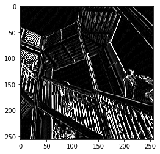

```python
new_x = int(size_x/2)
new_y = int(size_y/2)
newImage = np.zeros((new_x, new_y))
for x in range(0, size_x, 2):
  for y in range(0, size_y, 2):
    pixels = []
    pixels.append(i_transformed[x, y])
    pixels.append(i_transformed[x+1, y])
    pixels.append(i_transformed[x, y+1])
    pixels.append(i_transformed[x+1, y+1])
    pixels.sort(reverse=True)
    newImage[int(x/2),int(y/2)] = pixels[0]

# Plot the image. Note the size of the axes -- now 256 pixels instead of 512
plt.gray()
plt.grid(False)
plt.imshow(newImage)
#plt.axis('off')
plt.show()
```

## Section 4: Improving accuracy using Convolutions

```python
import tensorflow as tf
mnist = tf.keras.datasets.fashion_mnist
(X_train, y_train), (X_test, y_test) = mnist.load_data()
X_train = X_train / 255.0
X_test = X_test / 255.0
model = tf.keras.models.Sequential([
  tf.keras.layers.Flatten(),
  tf.keras.layers.Dense(128, activation=tf.nn.relu),
  tf.keras.layers.Dense(10, activation=tf.nn.softmax)
])
model.compile(optimizer=tf.optimizers.Adam(), loss='sparse_categorical_crossentropy', metrics=['accuracy'])
model.fit(X_train, y_train, epochs=5)

loss, acc = model.evaluate(X_test, y_test, verbose=0)
print("Loss on test set is ", loss)
print("Accuracy on test set is", acc)
```

```
Train on 60000 samples
Loss on test set is  0.342407232940197
Accuracy on test set is 0.8753
```

```python
# prepare the dataset
(X_train, y_train), (X_test, y_test) = tf.keras.datasets.fashion_mnist.load_data()
X_train = X_train.reshape(60000, 28, 28, 1)
X_train = X_train / 255.0
X_test = X_test.reshape(10000, 28, 28, 1)
X_test = X_test / 255.0
```

```python
# define the model
model = tf.keras.models.Sequential()
model.add(tf.keras.layers.Conv2D(64, (3,3), activation='relu', input_shape=(28, 28, 1)))
model.add(tf.keras.layers.MaxPooling2D(2, 2))
model.add(tf.keras.layers.Conv2D(64, (3,3), activation='relu'))
model.add(tf.keras.layers.MaxPooling2D(2,2))
model.add(tf.keras.layers.Flatten())
model.add(tf.keras.layers.Dense(128, activation='relu'))
model.add(tf.keras.layers.Dense(10, activation='softmax'))
```

```python
# complie the model
model.compile(optimizer=tf.optimizers.Adam(), loss='sparse_categorical_crossentropy', metrics=['accuracy'])
# model summary
model.summary()
```

```
Model: "sequential_10"
_________________________________________________________________
Layer (type)                 Output Shape              Param #
=================================================================
conv2d_2 (Conv2D)            (None, 26, 26, 64)        640
_________________________________________________________________
max_pooling2d_2 (MaxPooling2 (None, 13, 13, 64)        0
_________________________________________________________________
conv2d_3 (Conv2D)            (None, 11, 11, 64)        36928
_________________________________________________________________
max_pooling2d_3 (MaxPooling2 (None, 5, 5, 64)          0
_________________________________________________________________
flatten_9 (Flatten)          (None, 1600)              0
_________________________________________________________________
dense_21 (Dense)             (None, 128)               204928
_________________________________________________________________
dense_22 (Dense)             (None, 10)                1290
=================================================================
Total params: 243,786
Trainable params: 243,786
Non-trainable params: 0
_________________________________________________________________
```

```python
# train the model
model.fit(X_train, y_train, epochs=5)
```

```
Train on 60000 samples
```

```
<tensorflow.python.keras.callbacks.History at 0x7fb80c146668>
```

```python
loss, acc = model.evaluate(X_test, y_test, verbose=0)
print("Loss on test set is ", loss)
print("Accuracy on test set is", acc)
```

```
Loss on test set is  0.2482373044013977
Accuracy on test set is 0.9117
```

## Section 5: Using Convolutions with Complex Images

In Fashion MNIST classification, the subject is always in the `center` of a 28x28 image.

In this section, we will take it to the next level, training to recognize features in an image where the subject can be `anywhere` in the image!

Building a `horses-or-humans` classifier that will tell you if a given image contains a horse or a human, where the network is trained to recognize features that determine which is which.

### Get the dataset

```python
!wget --no-check-certificate \
    https://storage.googleapis.com/laurencemoroney-blog.appspot.com/horse-or-human.zip \
    -O ./data/horse-or-human.zip
```

```
--2019-11-20 22:50:34--  https://storage.googleapis.com/laurencemoroney-blog.appspot.com/horse-or-human.zip
Resolving storage.googleapis.com (storage.googleapis.com)... 216.58.207.240, 2a00:1450:400f:80c::2010
Connecting to storage.googleapis.com (storage.googleapis.com)|216.58.207.240|:443... connected.
HTTP request sent, awaiting response... 200 OK
Length: 149574867 (143M) [application/zip]
Saving to: ‘./data/horse-or-human.zip’

./data/horse-or-hum 100%[===================>] 142.65M  11.6MB/s    in 13s

2019-11-20 22:50:49 (10.8 MB/s) - ‘./data/horse-or-human.zip’ saved [149574867/149574867]
```

```python
import os
import zipfile

local_zip = './data/horse-or-human.zip'
zip_ref = zipfile.ZipFile(local_zip, 'r')
zip_ref.extractall('./data/horse-or-human')
zip_ref.close()

# Directory with our training horse pictures
train_horse_dir = os.path.join('./data/horse-or-human/horses')

# Directory with our training human pictures
train_human_dir = os.path.join('./data/horse-or-human/humans')
```

```python
# a pick view of the data
train_horse_names = os.listdir(train_horse_dir)
print(train_horse_names[:10])

train_human_names = os.listdir(train_human_dir)
print(train_human_names[:10])
```

```
['horse21-2.png', 'horse42-5.png', 'horse32-4.png', 'horse34-3.png', 'horse09-6.png', 'horse37-4.png', 'horse17-6.png', 'horse47-1.png', 'horse11-3.png', 'horse36-8.png']
['human14-14.png', 'human04-19.png', 'human09-13.png', 'human14-27.png', 'human16-28.png', 'human17-24.png', 'human17-25.png', 'human01-09.png', 'human13-30.png', 'human06-28.png']
```

```python
print('total training horse images:', len(os.listdir(train_horse_dir)))
print('total training human images:', len(os.listdir(train_human_dir)))
```

```
total training horse images: 500
total training human images: 527
```

### Visualization

```python
%matplotlib inline

import matplotlib.pyplot as plt
import matplotlib.image as mpimg

# Parameters for our graph; we'll output images in a 4x4 configuration
nrows = 4
ncols = 4

# Index for iterating over images
pic_index = 0

# Set up matplotlib fig, and size it to fit 4x4 pics
fig = plt.gcf()
fig.set_size_inches(ncols * 4, nrows * 4)

pic_index += 8
next_horse_pix = [os.path.join(train_horse_dir, fname)
                for fname in train_horse_names[pic_index-8:pic_index]]
next_human_pix = [os.path.join(train_human_dir, fname)
                for fname in train_human_names[pic_index-8:pic_index]]
```

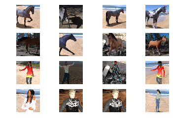

```python
for i, img_path in enumerate(next_horse_pix+next_human_pix):
  # Set up subplot; subplot indices start at 1
  sp = plt.subplot(nrows, ncols, i + 1)
  sp.axis('Off') # Don't show axes (or gridlines)
  img = mpimg.imread(img_path)
  plt.imshow(img)
plt.show()
```

### Data Preprocessing

```python
from tensorflow.keras.preprocessing.image import ImageDataGenerator

# All images will be rescaled by 1./255
train_datagen = ImageDataGenerator(rescale=1/255)

# Flow training images in batches of 128 using train_datagen generator
train_generator = train_datagen.flow_from_directory(
        './data/horse-or-human/',  # This is the source directory for training images
        target_size=(300, 300),  # All images will be resized to 150x150
        batch_size=128,
        # Since we use binary_crossentropy loss, we need binary labels
        class_mode='binary')
```

```
Found 1027 images belonging to 2 classes.
```

### Building a Small Model from Scratch

```python
import tensorflow as tf
model = tf.keras.models.Sequential([
    # Note the input shape is the desired size of the image 300x300 with 3 bytes color
    # This is the first convolution
    tf.keras.layers.Conv2D(16, (3,3), activation='relu', input_shape=(300, 300, 3)),
    tf.keras.layers.MaxPooling2D(2, 2),
    # The second convolution
    tf.keras.layers.Conv2D(32, (3,3), activation='relu'),
    tf.keras.layers.MaxPooling2D(2,2),
    # The third convolution
    tf.keras.layers.Conv2D(64, (3,3), activation='relu'),
    tf.keras.layers.MaxPooling2D(2,2),
    # The fourth convolution
    tf.keras.layers.Conv2D(64, (3,3), activation='relu'),
    tf.keras.layers.MaxPooling2D(2,2),
    # The fifth convolution
    tf.keras.layers.Conv2D(64, (3,3), activation='relu'),
    tf.keras.layers.MaxPooling2D(2,2),
    # Flatten the results to feed into a DNN
    tf.keras.layers.Flatten(),
    # 512 neuron hidden layer
    tf.keras.layers.Dense(512, activation='relu'),
    # Only 1 output neuron. It will contain a value from 0-1 where 0 for 1 class ('horses') and 1 for the other ('humans')
    tf.keras.layers.Dense(1, activation='sigmoid')
])
```

```python
model.summary()
```

```
Model: "sequential"
_________________________________________________________________
Layer (type)                 Output Shape              Param #
=================================================================
conv2d (Conv2D)              (None, 298, 298, 16)      448
_________________________________________________________________
max_pooling2d (MaxPooling2D) (None, 149, 149, 16)      0
_________________________________________________________________
conv2d_1 (Conv2D)            (None, 147, 147, 32)      4640
_________________________________________________________________
max_pooling2d_1 (MaxPooling2 (None, 73, 73, 32)        0
_________________________________________________________________
conv2d_2 (Conv2D)            (None, 71, 71, 64)        18496
_________________________________________________________________
max_pooling2d_2 (MaxPooling2 (None, 35, 35, 64)        0
_________________________________________________________________
conv2d_3 (Conv2D)            (None, 33, 33, 64)        36928
_________________________________________________________________
max_pooling2d_3 (MaxPooling2 (None, 16, 16, 64)        0
_________________________________________________________________
conv2d_4 (Conv2D)            (None, 14, 14, 64)        36928
_________________________________________________________________
max_pooling2d_4 (MaxPooling2 (None, 7, 7, 64)          0
_________________________________________________________________
flatten (Flatten)            (None, 3136)              0
_________________________________________________________________
dense (Dense)                (None, 512)               1606144
_________________________________________________________________
dense_1 (Dense)              (None, 1)                 513
=================================================================
Total params: 1,704,097
Trainable params: 1,704,097
Non-trainable params: 0
_________________________________________________________________
```

```python
from tensorflow.keras.optimizers import RMSprop

# compile the model
model.compile(loss='binary_crossentropy',
              optimizer=RMSprop(lr=0.001),
              metrics=['acc'])
```

### Train the model

```python
history = model.fit_generator(
      train_generator,
      steps_per_epoch=8,
      epochs=15,
      verbose=1)
```

### Runing the Model

```python
import numpy as np
# from google.colab import files
from keras.preprocessing import image

# uploaded = files.upload()

for fn in uploaded.keys():

  # predicting images
  path = '/content/' + fn
  img = image.load_img(path, target_size=(300, 300))
  x = image.img_to_array(img)
  x = np.expand_dims(x, axis=0)

  images = np.vstack([x])
  classes = model.predict(images, batch_size=10)
  print(classes[0])
  if classes[0]>0.5:
    print(fn + " is a human")
  else:
    print(fn + " is a horse")
```

[output not shown]

### Visualizing Intermediate Representations

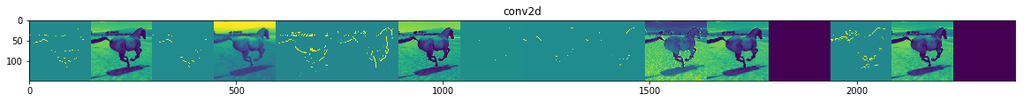

[figure not shown]

[figure not shown]

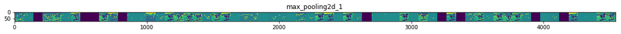

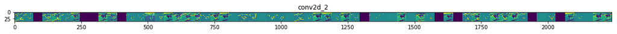

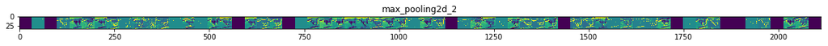

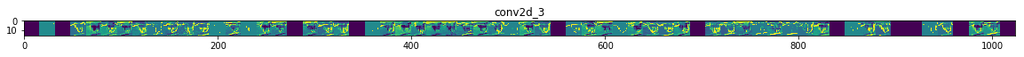

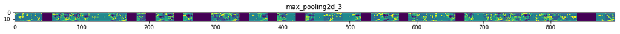

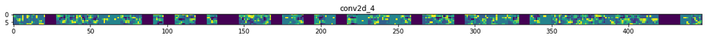

```python
import numpy as np
import random
from tensorflow.keras.preprocessing.image import img_to_array, load_img

# Let's define a new Model that will take an image as input, and will output
# intermediate representations for all layers in the previous model after
# the first.
successive_outputs = [layer.output for layer in model.layers[1:]]
#visualization_model = Model(img_input, successive_outputs)
visualization_model = tf.keras.models.Model(inputs = model.input, outputs = successive_outputs)
# Let's prepare a random input image from the training set.
horse_img_files = [os.path.join(train_horse_dir, f) for f in train_horse_names]
human_img_files = [os.path.join(train_human_dir, f) for f in train_human_names]
img_path = random.choice(horse_img_files + human_img_files)

img = load_img(img_path, target_size=(300, 300))  # this is a PIL image
x = img_to_array(img)  # Numpy array with shape (150, 150, 3)
x = x.reshape((1,) + x.shape)  # Numpy array with shape (1, 150, 150, 3)

# Rescale by 1/255
x /= 255

# Let's run our image through our network, thus obtaining all
# intermediate representations for this image.
successive_feature_maps = visualization_model.predict(x)

# These are the names of the layers, so can have them as part of our plot
layer_names = [layer.name for layer in model.layers]

# Now let's display our representations
for layer_name, feature_map in zip(layer_names, successive_feature_maps):
  if len(feature_map.shape) == 4:
    # Just do this for the conv / maxpool layers, not the fully-connected layers
    n_features = feature_map.shape[-1]  # number of features in feature map
    # The feature map has shape (1, size, size, n_features)
    size = feature_map.shape[1]
    # We will tile our images in this matrix
    display_grid = np.zeros((size, size * n_features))
    for i in range(n_features):
      # Postprocess the feature to make it visually palatable
      x = feature_map[0, :, :, i]
      x -= x.mean()
      x /= x.std()
      x *= 64
      x += 128
      x = np.clip(x, 0, 255).astype('uint8')
      # We'll tile each filter into this big horizontal grid
      display_grid[:, i * size : (i + 1) * size] = x
    # Display the grid
    scale = 20. / n_features
    plt.figure(figsize=(scale * n_features, scale))
    plt.title(layer_name)
    plt.grid(False)
    plt.imshow(display_grid, aspect='auto', cmap='viridis')
```